# Decoding Retail Transactions

MSDM CEP Proposal Presentation

Jake Evans

IBM 6540, Cal Poly Pomona

2026-08-11

# Introduction

## The Problem

Specialty retailers collect transaction logs every day, but most of that data never informs a decision:

- Promotions are planned on **intuition**, not evidence
- Marketing spend is spread **evenly** across categories
- No clear picture of **which customers drive revenue**

> “Without analytics, a transaction log is just a receipt pile.”

The result: budget leaks into segments that were never going to convert.

## Analytics Objective

**One objective, stated plainly:**

Determine how **product category** and **customer demographics** (age, gender) relate to **transaction value**, so promotional spend can be targeted at the highest-value segments.

Scope note: this proposal covers one year of point-of-sale transactions from a single specialty retailer.

## Why It Matters

- Targeted promotion is consistently cheaper than blanket discounting<sup>1</sup>
- Category-level insight feeds directly into **inventory** and **retail media** decisions
- The method generalizes: the same pipeline works for any transactional dataset
[^1]: Blanket discounts erode margin across all segments, including customers who would have purchased at full price.

# Literature Review

## Theoretical Grounding

- **Buyer behavior theory** (Howard and Sheth 1969) frames purchase outcomes as a function of buyer characteristics and stimulus (category/price) variables
- **Market segmentation** (Wedel and Kamakura 2000) justifies splitting customers by demographics before modeling response
- **RFM analysis** (Hughes 1994) supports transaction value as a managerially meaningful outcome

## Is the Data Adequate?

**What the data covers**

- Full year of transactions
- Demographics on every record
- Category, quantity, unit price

**What it doesn’t**

- No loyalty / repeat-purchase IDs across visits
- No marketing-exposure data
- Single retailer → limited generalizability

**Conclusion:** The data is useful for identifying customer segments and analyzing transaction value, but additional information, such as panel data and promotion records, would be needed to make any causal claims.

# Methods

## Data & Sampling

The dataset is the Kaggle **Retail Sales Dataset**, a point-of-sale extract with 1000 transactions recorded between January 2023 and December 2023. The average transaction value is **$477.12**, and 48.1% of transactions were made by female customers.<sup>1</sup>

**Show the import check**

```r
glimpse(sales)
```

```
Rows: 1,000
Columns: 9
$ transaction_id   <int> 1, 2, 3, 4, 5, 6, 7, 8, 9, 10, 11, 12, 13, 14, 15, 16…
$ date             <date> 2023-03-18, 2023-12-26, 2023-11-08, 2023-09-14, 2023…
$ customer_id      <chr> "CUST001", "CUST002", "CUST003", "CUST004", "CUST005"…
$ gender           <chr> "Male", "Male", "Female", "Female", "Female", "Male",…
$ age              <int> 39, 32, 58, 21, 21, 25, 49, 51, 28, 62, 42, 32, 27, 3…
$ product_category <chr> "Clothing", "Beauty", "Clothing", "Electronics", "Clo…
$ quantity         <int> 1, 2, 4, 4, 4, 3, 3, 4, 3, 2, 4, 1, 2, 1, 2, 2, 3, 1,…
$ price_per_unit   <dbl> 50, 25, 500, 500, 25, 500, 300, 30, 500, 500, 50, 25,…
$ total_amount     <dbl> 50, 50, 2000, 2000, 100, 1500, 900, 120, 1500, 1000, …
```

[^2]: Sample statistics are computed inline from the data, so they update automatically if the dataset changes.

## Data Wrangling

```r
sales_clean <- sales |>
  mutate(age_group = case_when(age < 30 ~ "18–29",
                               age < 45 ~ "30–44",
                               TRUE     ~ "45+")) |>
  group_by(product_category, age_group) |>
  summarize(across(c(quantity, total_amount), mean, .names = "avg_{.col}"),
            n = n(), .groups = "drop")
head(sales_clean)
```

```
# A tibble: 6 × 5
  product_category age_group avg_quantity avg_total_amount     n
  <chr>            <chr>            <dbl>            <dbl> <int>
1 Beauty           18–29             2.39             395.    70
2 Beauty           30–44             2.48             426.   111
3 Beauty           45+               2.64             502.   137
4 Clothing         18–29             2.62             512.    84
5 Clothing         30–44             2.33             474.   114
6 Clothing         45+               2.73             471.   164
```

## Sample Characteristics

Table 1

| Product Category | Transactions | Avg Age | Avg Quantity | Avg Transaction ($) |
| --- | --- | --- | --- | --- |
| Beauty | 318 | 41.5 | 2.53 | 452.00 |
| Clothing | 362 | 41.8 | 2.58 | 481.73 |
| Electronics | 320 | 40.8 | 2.47 | 496.89 |

## Revenue by Category

**Show plotting code**

```r
sales |>
  mutate(month = floor_date(date, "month")) |>
  group_by(month, product_category) |>
  summarize(revenue = sum(total_amount), .groups = "drop") |>
  ggplot(aes(month, revenue, color = product_category)) +
  geom_line(linewidth = 1.1) +
  geom_point(size = 2) +
  scale_y_continuous(labels = scales::dollar) +
  scale_color_manual(values = c("#C4820E", "#1E4D2B", "#6b7a8f")) +
  labs(x = NULL, y = "Monthly revenue",
       color = "Category",
       title = "Monthly revenue by product category") +
  theme_minimal(base_size = 18)
```

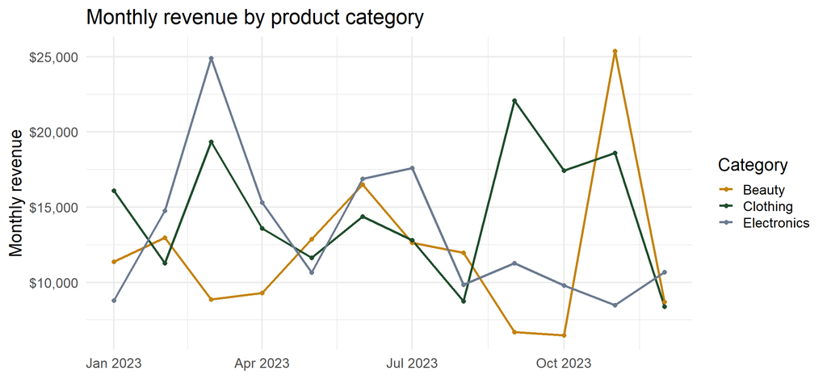

Figure 1

## Measures & Analytics Methods

**Measures**

- *Outcome:* transaction value (`total_amount`)
- *Predictors:* product category, age group, gender
- *Controls:* quantity, month (seasonality)

**Methods**

1. Descriptive segmentation (tables + visualization)
2. Multiple regression on transaction value
3. Logistic regression on *high-value transaction* (top quartile) membership

# Wrap-Up

## Expected Contribution

- A segment-level map of **where transaction value concentrates**
- A reproducible Quarto pipeline the retailer can rerun each quarter
- Evidence-based targeting recommendations for promotional spend

## References

Howard, John A., and Jagdish N. Sheth. 1969. *The Theory of Buyer Behavior*. John Wiley & Sons.

Hughes, Arthur M. 1994. *Strategic Database Marketing*. Probus Publishing.

Wedel, Michel, and Wagner A. Kamakura. 2000. *Market Segmentation: Conceptual and Methodological Foundations*. 2nd ed. Kluwer Academic Publishers.